# La Red del Sistema de Transporte Metro

MDS. René Rosado González

2023-05-08

### Introducción

A continuación realizaremos un análisis sobre la red del Sistema de Transporte Colectivo Metro. Para ello, será necesario que descargues la carpeta con la [Ubicación de líneas y estaciones del Sistema de Transporte Colectivo Metro](https://datos.cdmx.gob.mx/dataset/1b014317-ddb1-46c7-ac79-7330c652abe3/resource/288b10dd-4f21-4338-b1ed-239487820512/download/stcmetro_shp.zip) disponible en el [Portal de Datos Abiertos de la CDMX](https://datos.cdmx.gob.mx/). Una vez que la descarga haya finalizado, descomprime la carpeta y colócala en tu directorio de trabajo. Es importante que no modifiques ninguno de los archivos que contiene ya que se trade de un Sistema de Información Georreferenciado (GIS).

### Librerías

Trabajaremos utilizando el paradigma de `tidyverse` por lo que será necesario que instales y cargues las siguientes librerías

```r
# Instala - carga tidyverse
if(require(tidyverse) == FALSE){
  install.packages('tidyverse')
  library(tidyverse)
}else{
  library(tidyverse)
}

## Para trabajar con datos espaciales
# Instala - carga sf
if(require(sf) == FALSE){
  install.packages('sf')
  library(sf)
}else{
  library(sf)
}
# Instala - carga ggsn
if(require(ggsn) == FALSE){
  install.packages('ggsn')
  library(ggsn)
}else{
  library(ggsn)
}

## Para trabajar con grafos
# Instala - carga igraph
if(require(igraph) == FALSE){
  install.packages('igraph')
  library(igraph)
}else{
  library(igraph)
}
# Instala - carga tidygraph
if(require(tidygraph) == FALSE){
  install.packages('tidygraph')
  library(tidygraph)
}else{
  library(tidygraph)
}
# Instala - carga ggraph
if(require(ggraph) == FALSE){
  install.packages('ggraph')
  library(ggraph)
}else{
  library(ggraph)
}
```

### Datos

Carga el archivo `STC_Metro_estaciones_utm14n.shp` utilizando la función `read_sf` y asígnalo a un objeto llamado `estaciones`. Recuerda que puedes apoyarte en la documentación de la función usando `?read_sf` o consultando la página de la librería [`sf`](https://r-spatial.github.io/sf/)’

```r
# Carga el archivo con las coordenadas de las estaciones
estaciones = read_sf('../data/stcmetro_shp/STC_Metro_estaciones_utm14n.shp')
# Inspecciona el objeto
glimpse(estaciones)
```

```
## Rows: 195
## Columns: 10
## $ SISTEMA   <chr> "STC Metro", "STC Metro", "STC Metro", "STC Metro", "STC Met…
## $ NOMBRE    <chr> "Pantitlán", "Zaragoza", "Gomez Farías", "Boulevard Puerto A…
## $ LINEA     <chr> "01", "01", "01", "01", "01", "01", "01", "01", "01", "01", …
## $ EST       <chr> "01", "02", "03", "04", "05", "06", "07", "08", "09", "10", …
## $ CVE_EST   <chr> "STC0101", "STC0102", "STC0103", "STC0104", "STC0105", "STC0…
## $ CVE_EOD17 <chr> "05014", "05020", "05007", "05003", "05001", "05012", "05017…
## $ TIPO      <chr> "Terminal / Transbordo", "Intermedia", "Intermedia", "Interm…
## $ ALCALDIAS <chr> "Venustiano Carranza", "Venustiano Carranza", "Venustiano Ca…
## $ AÑO       <dbl> 1984, 1969, 1969, 1969, 1969, 1969, 1969, 1969, 1969, 1969, …
## $ geometry  <POINT [°]> POINT Z (-99.07474 19.41633 0), POINT Z (-99.08229 19.…
```

```r
# Carga el archivo con las coordenadas de las líneas
lineas = read_sf('../data/stcmetro_shp/STC_Metro_lineas_utm14n.shp')
# Inspecciona el objeto
glimpse(lineas)
```

```
## Rows: 12
## Columns: 4
## $ SISTEMA  <chr> "STC Metro", "STC Metro", "STC Metro", "STC Metro", "STC Metr…
## $ LINEA    <chr> "1", "2", "3", "4", "5", "6", "7", "8", "9", "A", "B", "12"
## $ RUTA     <chr> "Observatorio - Pantitlàn", "Cuatro Caminos - Tasqueña", "Ind…
## $ geometry <LINESTRING [m]> LINESTRING Z (478958.1 2144..., LINESTRING Z (477345.7 2151..…
```

Observa que la columna `LINEA` es distinta en el tibble de `estaciones` y el de `lineas`. Realiza la siguiente corrección removiendo el cero (`0`) utilizando la función `str_remove()`. Asegúrate de utilizar la expresión regular adecuada para no eliminar el número `10`.

```r
estaciones = estaciones %>%
  # Remueve los ceros para los número menores a 10
  mutate(LINEA = str_remove(LINEA,'^0'))
# Inspecciona el objeto
glimpse(estaciones)
```

```
## Rows: 195
## Columns: 10
## $ SISTEMA   <chr> "STC Metro", "STC Metro", "STC Metro", "STC Metro", "STC Met…
## $ NOMBRE    <chr> "Pantitlán", "Zaragoza", "Gomez Farías", "Boulevard Puerto A…
## $ LINEA     <chr> "1", "1", "1", "1", "1", "1", "1", "1", "1", "1", "1", "1", …
## $ EST       <chr> "01", "02", "03", "04", "05", "06", "07", "08", "09", "10", …
## $ CVE_EST   <chr> "STC0101", "STC0102", "STC0103", "STC0104", "STC0105", "STC0…
## $ CVE_EOD17 <chr> "05014", "05020", "05007", "05003", "05001", "05012", "05017…
## $ TIPO      <chr> "Terminal / Transbordo", "Intermedia", "Intermedia", "Interm…
## $ ALCALDIAS <chr> "Venustiano Carranza", "Venustiano Carranza", "Venustiano Ca…
## $ AÑO       <dbl> 1984, 1969, 1969, 1969, 1969, 1969, 1969, 1969, 1969, 1969, …
## $ geometry  <POINT [°]> POINT Z (-99.07474 19.41633 0), POINT Z (-99.08229 19.…
```

### Generar mapas con `ggplot2`

Para generar mapas con `ggplot2` podemos seguir la misma sintaxis de siempre, solo es necesario trabajar con `geom_sf` para incluir nuestras capas de información.

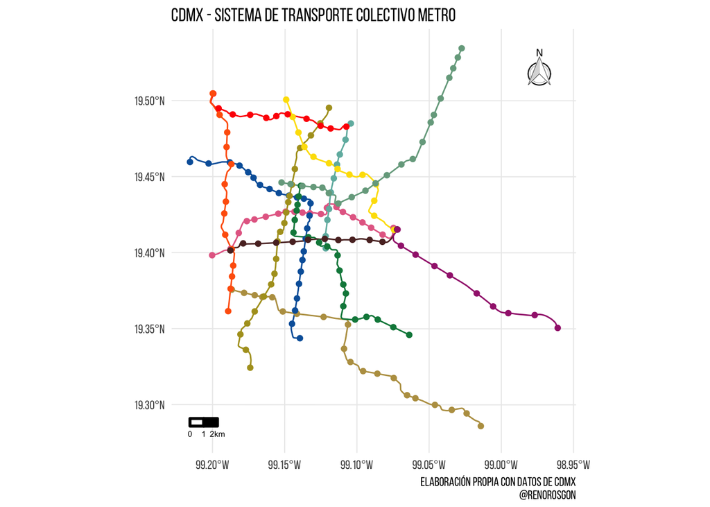

```r
# Crea un lienzo en blanco
ggplot() +
  # Agrega la capa de lineas y colorea por LINEA
  geom_sf(data = lineas, aes(col = LINEA)) +
  # Agrega la capa de estaciones y colorea por LINEA
  geom_sf(data = estaciones, aes(col = LINEA)) +
  # Modifica la escala de colores con los colores oficiales de cada línea.
  scale_color_manual(
    values = c('#E56C93','#B99E51','#0461A9','#AF9E22',
               '#70B7AE','#FDDF00','#FE0F01','#FF6209',
               '#088649','#5B2C2B','#A3277C','#77A88D')
  ) +
  # Agrega un título y la fuente de tu mapa
  labs(
    title = 'CDMX - Sistema de Transporte Colectivo Metro',
    caption = 'Elaboración propia con datos de CDMX\n@renorosgon'
       ) +
  # Dado que estamos trabajando un mapa es importante agregar lo siguiente:
  # Agrega una rosa de los vientos usando la función `north` de ggsn
  north(lineas, location = 'topright') +
  # Agrega una escala cartográfica usando la función `scalebar` de ggsn
  scalebar(lineas, transform = FALSE, dist_unit = 'km', dist = 1,
           location = "bottomleft", st.size = 2) +
  # Modifica el tema
  theme_minimal()  +
  theme(
    # Elimina las leyendas
    legend.position = 'none',
    # Elimina el título de los ejes
    axis.title = element_blank(),
    # Modifica la tipografía por tu favorita
    text = element_text(family = 'Bebas Neue')
    )
```

### Construir un una red usando `tidygraph`

Ahora construiremos una red a partir de la información espacial. Comenzaremos por construir los nodos de nuestra red utilizando el tibble con las `estaciones`. Para ello, será necesario hacer las siguientes operaciones:

```r
# Crea el objeto nodos
nodos = estaciones %>%
  # Cuenta el número de veces que aparece el NOMBRE de cada estación
  count(NOMBRE) %>%
  # Calcula el centroide de cada estación usando `st_centroid`
  mutate(geometry = st_centroid(geometry))

# Revisa el resultado
glimpse(nodos)
```

```
## Rows: 163
## Columns: 3
## $ NOMBRE   <chr> "Acatitla", "Aculco", "Agrícola Oriental", "Allende", "Apatla…
## $ n        <int> 1, 1, 1, 1, 1, 1, 1, 2, 1, 1, 1, 2, 1, 2, 1, 1, 1, 1, 1, 1, 1…
## $ geometry <POINT [°]> POINT (-99.00567 19.36472), POINT (-99.1077 19.37321), …
```

Ahora construiremos las relaciones entre las estaciones (`nodos`) con las siguientes operaciones:

```r
# Crea el objeto ejes
ejes = nodos %>%
  # Concatena por la izquierda el objeto `estacionees`
  left_join(
    # Elimina la geometría del objeto estaciones
    st_drop_geometry(estaciones),
    # Concatena usando la columna nombre
    by = 'NOMBRE'
    ) %>%
  # Ordena por la clave de la estación
  arrange(CVE_EST) %>%
  # Crear la reación DE - HACIA
  with_groups(
    # Agrupa por LINEA
    .groups = LINEA,
    # Muta el tibble
    mutate,
    # Crea la columna `to` con el NOMBRE de la estación inmediata usando `lead`
    to = lead(NOMBRE),
    # Crea la columna `geometry_to` con el NOMBRE de la estación inmediata `lead`
    geometry_to = lead(geometry),
  ) %>%
  # Flitra los NA en la columna `to`
  filter(!is.na(to)) %>%
  mutate(
    # Crea el eje georreferenciado
    eje = st_sfc(
      # Función map2 se lee así
      map2(
        # Para coada combinación de .x y .y
        .x = geometry, .y = geometry_to,
        # Aplica la siguiente función
        .f = ~{st_union(c(.x, .y)) %>% st_cast("LINESTRING")}
        )
      )
    ) %>%
  # Selecciona las columna NOMBRE como `from`, y las columnas `to` y `eje
  select(
    from = NOMBRE, to , eje
  ) %>%
  # Elimina la geometría original
  st_drop_geometry() %>%
  # Transforma a un nuevo objeto sf con el crs de estaciones
  st_sf(crs = st_crs(estaciones))

# Revisa el resultado
glimpse(ejes)
```

```
## Rows: 183
## Columns: 3
## $ from <chr> "Pantitlán", "Zaragoza", "Gomez Farías", "Boulevard Puerto Aéreo"…
## $ to   <chr> "Zaragoza", "Gomez Farías", "Boulevard Puerto Aéreo", "Balbuena",…
## $ eje  <LINESTRING [°]> LINESTRING (-99.0733 19.415..., LINESTRING (-99.08229 …
```

A partir de nuestros `nodos` y `ejes` construiremos una `red` no direccionada utilizando `tbl_graph`.

```r
# Crea un objeto tbl_graph
red = tbl_graph(
  nodes = nodos,
  edges = as_tibble(ejes),
  directed = FALSE
)

# Luce así
print(red)
```

```
## # A tbl_graph: 163 nodes and 183 edges
## #
## # An undirected simple graph with 1 component
## #
## # A tibble: 163 × 3
##   NOMBRE                n             geometry
##   <chr>             <int>          <POINT [°]>
## 1 Acatitla              1 (-99.00567 19.36472)
## 2 Aculco                1  (-99.1077 19.37321)
## 3 Agrícola Oriental     1 (-99.06957 19.40462)
## 4 Allende               1 (-99.13687 19.43556)
## 5 Apatlaco              1  (-99.10949 19.3791)
## 6 Aquiles Serdán        1 (-99.19535 19.49064)
## # … with 157 more rows
## #
## # A tibble: 183 × 3
##    from    to                                      eje
##   <int> <int>                         <LINESTRING [°]>
## 1   107   162  (-99.0733 19.41552, -99.08229 19.41192)
## 2    58   162 (-99.08229 19.41192, -99.09021 19.41648)
## 3    17    58 (-99.09021 19.41648, -99.09626 19.41994)
## # … with 180 more rows
```

Ahora que tenemos nuestra red, podemos calcular algunos atributos de nuestros nodos y nuestros ejes.

```r
red = red %>%
  # Activa los ejes
  activate(edges) %>%
  # Propiedades de los ejes
  mutate(
    # Calcula la longitud de cada eje
    longitud = st_length(eje),
    # Betweenness: Con qué frecuencia el eje está en el camino más corto
    betweenness = edge_betweenness(red, weights = longitud)
  ) %>%
  # Activate notes
  activate(nodes) %>%
  # Some node properties
  mutate(
    # Grado (vecinos): número de nodos con los que estoy conectado
    vecinos = degree(red),
    # Importancia: sum of the weights (importance)
    importancia = strength(red),
    # Intermediación(betweenness): Con qué frecuencia el nodo está en el camino más corto
    betweenness = betweenness(red),
    # Cercanía: distancia o cercanía con otros nodos
    cercania = closeness(red)
  )

# Luce así
print(red)
```

```
## # A tbl_graph: 163 nodes and 183 edges
## #
## # An undirected simple graph with 1 component
## #
## # A tibble: 163 × 7
##   NOMBRE             n             geometry vecinos importancia betwee…¹ cerca…²
##   <chr>          <int>          <POINT [°]>   <dbl>       <dbl>    <dbl>   <dbl>
## 1 Acatitla           1 (-99.00567 19.36472)       2           2     477  3.86e-4
## 2 Aculco             1  (-99.1077 19.37321)       2           2    1579. 5.66e-4
## 3 Agrícola Orie…     1 (-99.06957 19.40462)       2           2    1232  5.45e-4
## 4 Allende            1 (-99.13687 19.43556)       2           2     272. 6.62e-4
## 5 Apatlaco           1  (-99.10949 19.3791)       2           2    1663. 5.94e-4
## 6 Aquiles Serdán     1 (-99.19535 19.49064)       2           2     337. 4.28e-4
## # … with 157 more rows, and abbreviated variable names ¹betweenness, ²cercania
## #
## # A tibble: 183 × 5
##    from    to                                      eje longitud betweenness
##   <int> <int>                         <LINESTRING [°]>      [m]       <dbl>
## 1   107   162  (-99.0733 19.41552, -99.08229 19.41192)    1024.         581
## 2    58   162 (-99.08229 19.41192, -99.09021 19.41648)     973.         579
## 3    17    58 (-99.09021 19.41648, -99.09626 19.41994)     742.         681
## # … with 180 more rows
```

### Visualizar una red con `ggraph`

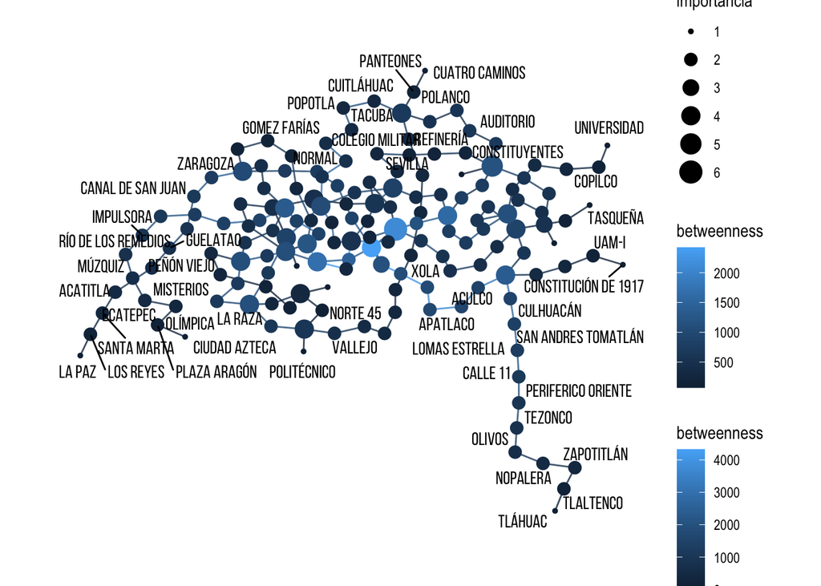

```r
# Inicia un lienzo ggraph usando 'lgl' como layout
ggraph(red, layout = 'lgl') +
  # Agrega los ejes
  geom_edge_link(
    # Colorea por intermediación (betweenness)
    aes(col = betweenness),
    # Modifica los estilos de los segmentos
    linewidth = 1, lineend = 'round', alpha = 0.8
    ) +
  # Agrega los nodos
  geom_node_point(
    # Colorea por intermediación (betweenness) y fija el tamaño por importancia
    aes(col = betweenness, size = importancia)
    ) +
  # Agrega el NOMBRE de cada estación a los nodos
  geom_node_text(aes(label = NOMBRE), repel = T, family = 'Bebas Neue') +
  # Modifica el tema
  theme_graph()
```

### Pasar de `tidygraph` a `sf`

Para convertir los elementos de nuestra `red` a objetos `sf`, dado que las geomterías siguen contenidas en el `tbl_graph`, basta con utilizar la función `as_tibble`, seguida de la función `st_as_sf`.

```r
# Extraer los nodos como sf
nodos_red = red %>%
  activate(nodes) %>%
  as_tibble() %>%
  st_as_sf() %>%
  # Agregamos la información de las estaciones y lineas
  left_join(st_drop_geometry(estaciones),by = 'NOMBRE') %>%
  left_join(st_drop_geometry(lineas), by = c('SISTEMA','LINEA')) %>%
  # Modificamos la columna LINEA para homologarla
  mutate(LINEA = paste0('Línea ', LINEA))

# Luce así
glimpse(nodos_red)
```

```
## Rows: 195
## Columns: 16
## $ NOMBRE      <chr> "Acatitla", "Aculco", "Agrícola Oriental", "Allende", "Apa…
## $ n           <int> 1, 1, 1, 1, 1, 1, 1, 2, 2, 1, 1, 1, 2, 2, 1, 2, 2, 1, 1, 1…
## $ geometry    <POINT [°]> POINT (-99.00567 19.36472), POINT (-99.1077 19.37321…
## $ vecinos     <dbl> 2, 2, 2, 2, 2, 2, 2, 4, 4, 2, 2, 2, 4, 4, 1, 4, 4, 2, 2, 2…
## $ importancia <dbl> 2, 2, 2, 2, 2, 2, 2, 4, 4, 2, 2, 2, 4, 4, 1, 4, 4, 2, 2, 2…
## $ betweenness <dbl> 477.0000, 1578.7333, 1232.0000, 271.5033, 1663.4000, 336.6…
## $ cercania    <dbl> 0.0003862495, 0.0005659310, 0.0005452563, 0.0006622517, 0.…
## $ SISTEMA     <chr> "STC Metro", "STC Metro", "STC Metro", "STC Metro", "STC M…
## $ LINEA       <chr> "Línea A", "Línea 8", "Línea A", "Línea 2", "Línea 8", "Lí…
## $ EST         <chr> "07", "13", "02", "12", "12", "02", "09", "15", "12", "08"…
## $ CVE_EST     <chr> "STCLA07", "STC0813", "STCLA02", "STC0212", "STC0812", "ST…
## $ CVE_EOD17   <chr> "05165", "05134", "05166", "05041", "05135", "05120", "050…
## $ TIPO        <chr> "Intermedia", "Intermedia", "Intermedia", "Intermedia", "I…
## $ ALCALDIAS   <chr> "Iztapalapa", "Iztapalapa", "Iztacalco", "Cuauhtémoc", "Iz…
## $ AÑO         <dbl> 1991, 1994, 1991, 1970, 1994, 1988, 1981, 1994, 2012, 1984…
## $ RUTA        <chr> "Pantitlán - La Paz", "Garibaldi - Constitución de 1917", …
```

```r
# Extraer los ejes como sf
ejes_red = red %>%
  activate(edges) %>%
  as_tibble() %>%
  st_as_sf() %>%
  # Realiza un spatial_join (st_join) con los ejes originales
  st_join(
    # Renombra las columnas "from" y "to" agregando el prefijo 'NOMBRE_'
    rename(ejes, NOMBRE_from = from, NOMBRE_to = to),
    # Fija largest = TRUE (revisa ?st_join para entender qué hace)
    largest = TRUE
    ) %>%
  # Agregamos la información de las estaciones y lineas
  left_join(
    st_drop_geometry(select(estaciones, NOMBRE, LINEA)),
    by = c('NOMBRE_from'='NOMBRE')
    ) %>%
  left_join(
    st_drop_geometry(select(estaciones, NOMBRE, LINEA)),
    by = c('NOMBRE_to'='NOMBRE'),
    suffix = c('_from', '_to')
    ) %>%
  # Filtra las observaciones de la misma LINEA
  filter(LINEA_from == LINEA_to) %>%
  # Elimina LINEA_to
  select(-LINEA_to) %>%
  # Renombre LINEA_from como LINEA
  rename(LINEA = LINEA_from) %>%
  # Agrega lla información de la línea
  left_join(st_drop_geometry(lineas), by = 'LINEA')  %>%
  # Modificamos la columna LINEA para homologarla
  mutate(LINEA = paste0('Línea ', LINEA))

# Luce así
glimpse(ejes_red)
```

```
## Rows: 183
## Columns: 10
## $ from        <int> 107, 58, 17, 11, 11, 92, 23, 23, 86, 70, 70, 12, 12, 39, 6…
## $ to          <int> 162, 162, 58, 17, 92, 132, 132, 86, 112, 112, 125, 125, 39…
## $ eje         <LINESTRING [°]> LINESTRING (-99.0733 19.415..., LINESTRING (-99…
## $ longitud    [m] 1024.3905 [m], 973.1549 [m], 742.0542 [m], 781.6198 [m], 833…
## $ betweenness <dbl> 581, 579, 681, 809, 939, 1069, 2423, 2380, 2368, 900, 884,…
## $ NOMBRE_from <chr> "Pantitlán", "Zaragoza", "Gomez Farías", "Boulevard Puerto…
## $ NOMBRE_to   <chr> "Zaragoza", "Gomez Farías", "Boulevard Puerto Aéreo", "Bal…
## $ LINEA       <chr> "Línea 1", "Línea 1", "Línea 1", "Línea 1", "Línea 1", "Lí…
## $ SISTEMA     <chr> "STC Metro", "STC Metro", "STC Metro", "STC Metro", "STC M…
## $ RUTA        <chr> "Observatorio - Pantitlàn", "Observatorio - Pantitlàn", "O…
```

Podemos replicar el grafo anterior aprovechando las coordenadas de nuestro sistema.

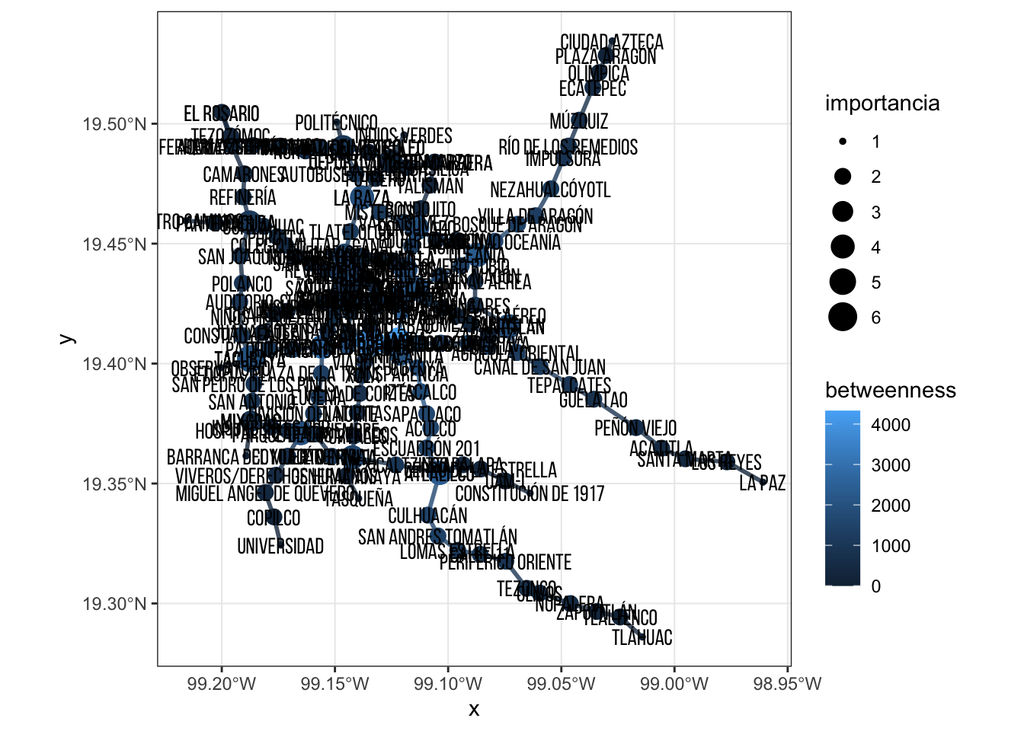

```r
# Inicia un lienzo ggplot2
ggplot() +
  # Agrega los ejes
  geom_sf(data = ejes_red,
    # Colorea por intermediación (betweenness)
    aes(col = betweenness),
    # Modifica los estilos de los segmentos
    linewidth = 1, lineend = 'round', alpha = 0.8
    ) +
  # Agrega los nodos
  geom_sf(data = nodos_red,
    # Colorea por intermediación (betweenness) y fija el tamaño por importancia
    aes(col = betweenness, size = importancia)
    ) +
  # Agrega el NOMBRE de cada estación a los nodos
  geom_sf_text(data = nodos_red, aes(label = NOMBRE), family = 'Bebas Neue') +
  # Modifica el tema
  theme_bw()
```

Ahora podemos jugar con la estética

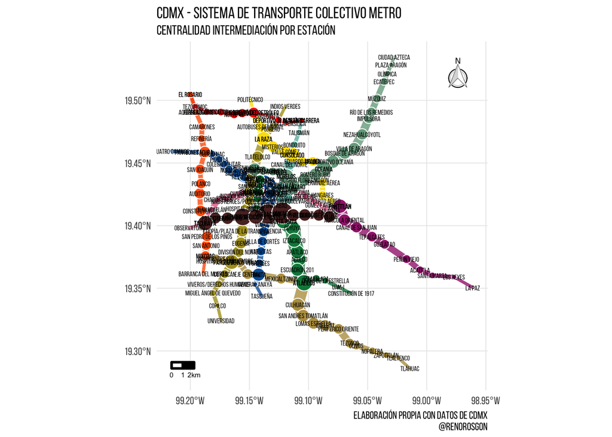

```r
# Inicia un lienzo ggplot2
ggplot() +
  # Agrega los ejes
  geom_sf(data = ejes_red,
    # Colorea por LINEA y define el grosor por intermediación (betweenness)
    aes(linewidth = betweenness, col = LINEA),
    # Modifica los estilos de los segmentos
    lineend = 'round', alpha = 0.8
    ) +
  # Modifica la escala de colores con los colores oficiales de cada línea.
  scale_color_manual(
    values = c('#E56C93','#B99E51','#0461A9','#AF9E22',
               '#70B7AE','#FDDF00','#FE0F01','#FF6209',
               '#088649','#5B2C2B','#A3277C','#77A88D')
  ) +
  # Agrega los nodos
  geom_sf(data = nodos_red,
    # Colorea por LINEA y define el grosor por intermediación (betweenness)
    aes(fill = LINEA, size = betweenness),
    # Modifica la forma para tener puntos con contornos blancos
    shape = 21, col = 'white'
    ) +
  # Modifica la escala de colores con los colores oficiales de cada línea.
  scale_fill_manual(
    values = c('#E56C93','#B99E51','#0461A9','#AF9E22',
               '#70B7AE','#FDDF00','#FE0F01','#FF6209',
               '#088649','#5B2C2B','#A3277C','#77A88D')
  ) +
  # Agrega el NOMBRE de cada estación a los nodos
  geom_sf_text(data = nodos_red, aes(label = NOMBRE),
               family = 'Bebas Neue', size = 2) +
  # Modifica el rango de tamaños
  scale_size(range = c(0,8)) +
  # Expande los Ejes
  scale_x_continuous(expand = c(0.01,0.01)) +
  scale_y_continuous(expand = c(0.01,0.01)) +
  # Agrega un título y la fuente de tu mapa
  labs(
    title = 'CDMX - Sistema de Transporte Colectivo Metro',
    subtitle = 'Centralidad intermediación por estación',
    caption = 'Elaboración propia con datos de CDMX\n@renorosgon'
       ) +
  # Dado que estamos trabajando un mapa es importante agregar lo siguiente:
  # Agrega una rosa de los vientos usando la función `north` de ggsn
  north(nodos_red, location = 'topright') +
  # Agrega una escala cartográfica usando la función `scalebar` de ggsn
  scalebar(nodos_red, transform = TRUE, dist_unit = 'km', dist = 1,
           location = "bottomleft", st.size = 2) +
  # Modifica el tema
  theme_minimal()  +
  theme(
    # Elimina las leyendas
    legend.position = 'none',
    # Elimina el título de los ejes
    axis.title = element_blank(),
    # Modifica la tipografía por tu favorita
    text = element_text(family = 'Bebas Neue')
    )
```